# Reproducible Research

## Part 1 Loading and preprocessing the data

### Exercise 1.A.

*Load the data (i.e. readr::read_csv())*

```r
if(!file.exists('activity.csv')){
    unzip('activity.zip')
}
activityData <- read_csv('activity.csv',show_col_types = FALSE)
```

### Exercise 1.B

*Process/transform the data (if necessary) into a format suitable for your analysis*

- Looking ahead, we will need to create a time stamp variable using a transformation of the intervals variable.
- We will also transform the time variable into a timelapse format that is convenient for making time-series plots.

```r
activityData$interval <- activityData$interval

activityData$time <- sprintf("%04.0f", activityData$interval)
activityData$time <- gsub("([0-9]{1,2})([0-9]{2})", "\\1:\\2", activityData$time)

# Create Day and Hour Variables for Imputation and Day Type Analysis
activityData <- activityData %>% mutate( Day = wday(date)) # lubdridate R package
activityData <- activityData %>% mutate( Hour = substr(time, start = 1, stop = 2))
```

```r
tail(activityData,2)
```

```
## # A tibble: 2 x 6
##   steps date       interval time    Day Hour
##   <dbl> <date>        <dbl> <chr> <dbl> <chr>
## 1    NA 2012-11-30     2350 23:50     6 23
## 2    NA 2012-11-30     2355 23:55     6 23
```

## Part 2

### Exercise 2.A

*Calculate the total number of steps taken per day*

Working in units of daily step count

```r
daily_step_total <- activityData %>%
    group_by(date) %>%  # using tidyverse
    summarise(daily_steps=sum(steps,na.rm=TRUE))

head(daily_step_total,4)
```

```
## # A tibble: 4 x 2
##   date       daily_steps
##   <date>           <dbl>
## 1 2012-10-01           0
## 2 2012-10-02         126
## 3 2012-10-03       11352
## 4 2012-10-04       12116
```

### Exercise 2.B

*Make a histogram of the total number of steps taken each day*

The approach to take using {ggplot2} is to apply `geom_bar()`, and apply it to the daily step totals

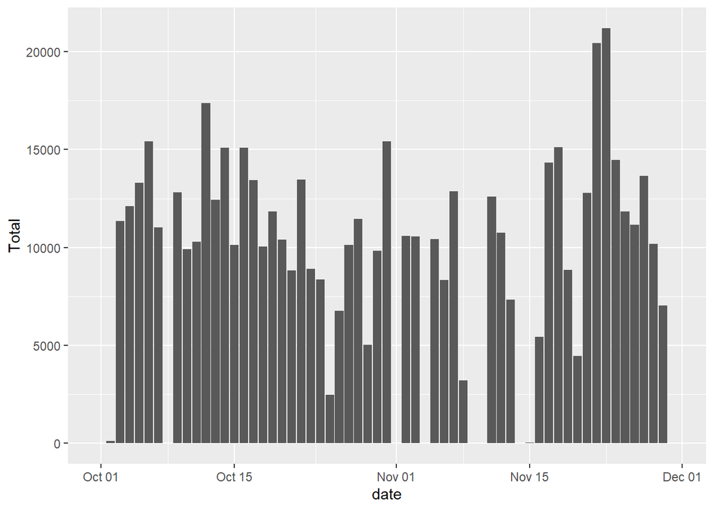

```r
activityData %>% group_by(date) %>%
    summarise(steps=sum(steps,na.rm=TRUE)) %>%
    ggplot(aes(x=date,y=steps)) + geom_bar(stat="identity") +
    ylab("Total")
```

### Exercise 2.C

*Calculate and report the mean and median total number of steps taken per day*

The mean and median of the daily step counts for the period can be found in the following summary.

```r
daily_step_summary <- daily_step_total%>% summarize(
    mean_daily_steps= mean(daily_steps),
    median_daily_steps = median(daily_steps),
    total_daily_steps = sum(daily_steps))

daily_step_summary
```

```
## # A tibble: 1 x 3
##   mean_daily_steps median_daily_steps total_daily_steps
##              <dbl>              <dbl>             <dbl>
## 1            9354.              10395            570608
```

```r
Mean_Daily_Steps <- daily_step_summary %>% pull(mean_daily_steps)
Median_Daily_Steps <- daily_step_summary%>% pull(median_daily_steps)
Total_Daily_Steps <- daily_step_summary%>% pull(total_daily_steps)
```

- Mean: 9,354
- Median: 10,395
- Total: 570,608

## Part 3

**What is the average daily activity pattern?**

```r
mean_steps_per_interval <- activityData %>%
    group_by(time) %>%
    summarise(meanSteps = mean(steps,na.rm=TRUE))

# Useful for plot later on
mean_steps_per_interval$time = factor(mean_steps_per_interval$time,ordered=TRUE)
```

### Exercise 3.A

*Make a time series plot (i.e. `type = “l”)` of the 5-minute interval (x-axis) and the average number of steps taken, averaged across all days (y-axis)*

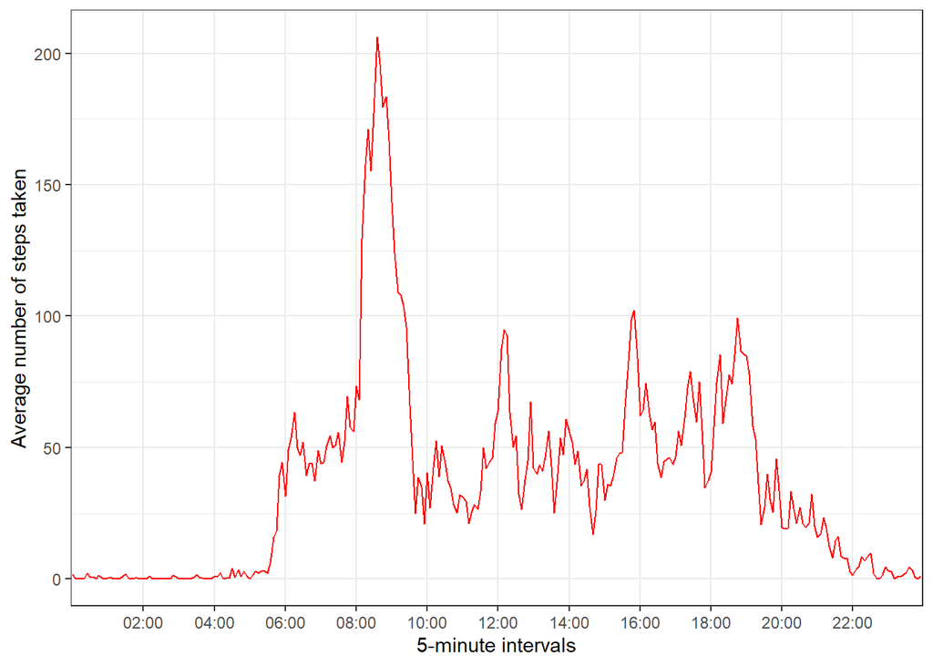

```r
mean_steps_per_interval %>%
    ggplot(aes(x=time, y=meanSteps,group=1)) +
    geom_line(col="red") +
    xlab("5-minute intervals") +
    ylab("Average number of steps taken") +
    scale_x_discrete(breaks=mean_steps_per_interval$time[24*(1:11)+1])+
    theme_bw()
```

### Exercise 3.B

*Which 5-minute interval, on average across all the days in the dataset, contains the maximum number of steps?*

```r
max_steps <- which.max(mean_steps_per_interval$meanSteps)

time_max_steps <-activityData$time[max_steps]
```

- Most Steps at: 08:35

## Part 4

**Imputing missing values**

### Exercise 4.A

*Calculate and report the total number of missing values in the dataset*

```r
numMissingValues <- sum(is.na(activityData$steps))
```

- Number of missing values: 2,304

### Exercise 4.B

*Devise a strategy for filling in all of the missing values in the dataset.*

```r
impute_data <- activityData %>%
    group_by(Day,Hour) %>%
    summarise(impute_steps=mean(steps,na.rm=TRUE)) %>%
    mutate(impute_steps=round(impute_steps))
head(impute_data,10)
```

```
## # A tibble: 10 x 3
## # Groups:   Day [1]
##      Day Hour  impute_steps
##    <dbl> <chr>        <dbl>
##  1     1 00               1
##  2     1 01               1
##  3     1 02               0
##  4     1 03               0
##  5     1 04               2
##  6     1 05               1
##  7     1 06               7
##  8     1 07              22
##  9     1 08              96
## 10     1 09              41
```

### Exercise 4.C

*Create a new dataset that is equal to the original dataset but with the missing data filled in.*

In the previous section, a dataframe of imputation values, called “impute_data” was created. This dataframe is joined to the main dataset using a join function, and the missing values are imputated using a coalesce operations.

```r
activityDataImputed <- activityData %>%
    left_join(impute_data,by=c("Day","Hour")) %>%
    mutate(steps = coalesce(steps,impute_steps))
```

```r
head(activityDataImputed)
```

```
## # A tibble: 6 x 7
##   steps date       interval time    Day Hour  impute_steps
##   <dbl> <date>        <dbl> <chr> <dbl> <chr>        <dbl>
## 1     1 2012-10-01        0 00:00     2 00               1
## 2     1 2012-10-01        5 00:05     2 00               1
## 3     1 2012-10-01       10 00:10     2 00               1
## 4     1 2012-10-01       15 00:15     2 00               1
## 5     1 2012-10-01       20 00:20     2 00               1
## 6     1 2012-10-01       25 00:25     2 00               1
```

### Exercise 4.D

*Make a histogram of the total number of steps taken each day*

The previous histogram is re-created with the updated data

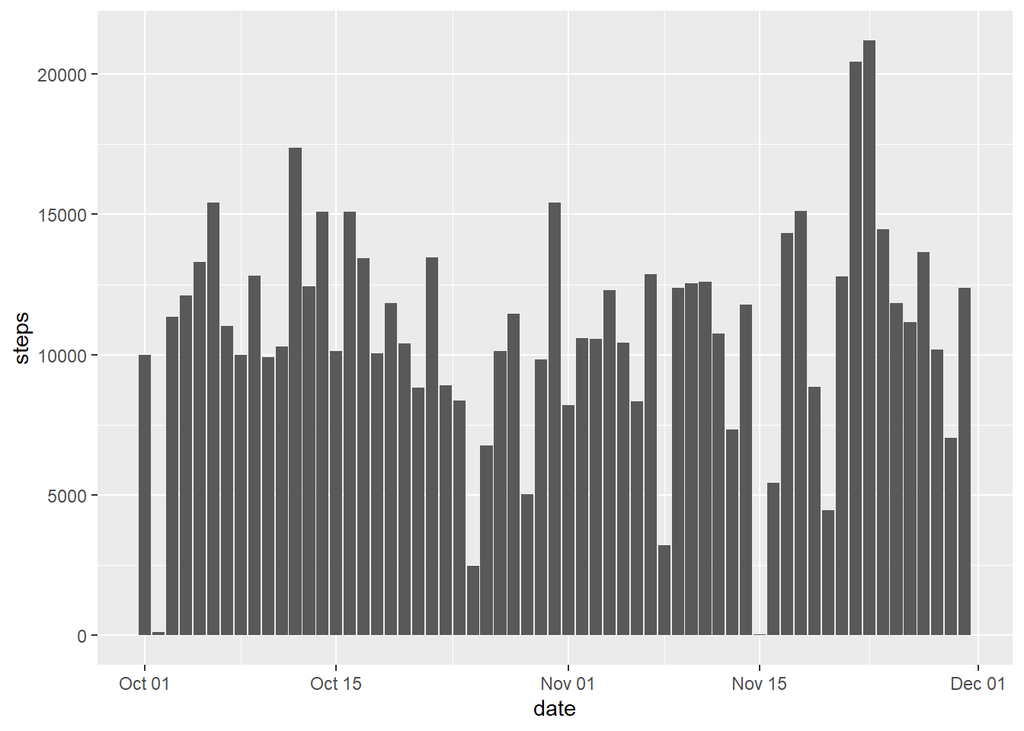

```r
activityDataImputed %>% group_by(date) %>%
    summarise(steps=sum(steps,na.rm=TRUE)) %>%
    ggplot(aes(x=date,y=steps)) + geom_bar(stat="identity")
```

### Exercise 4.E

*Calculate and report the mean and median total number of steps taken per day.*

```r
stepsByDayImputed <- activityDataImputed %>%
    group_by(date) %>%  # using tidyverse
    summarise(daily_steps=sum(steps,na.rm=TRUE)) %>%
    summarize(
    mean_daily_steps= mean(daily_steps),
    median_daily_steps = median(daily_steps),
    total_daily_steps = sum(daily_steps))


stepsByDayMeanImputed <- stepsByDayImputed$mean_daily_steps
stepsByDayMedianImputed <- stepsByDayImputed$median_daily_steps
```

- Mean (Imputed): 10,822
- Median (Imputed): 11,015

## Part 5

*Are there differences in activity patterns between weekdays and weekends?*

### Exercise 5.A

Create a new factor variable in the dataset with two levels – “weekday” and “weekend” indicating whether a given date is a weekday or weekend day.

```r
#lubridate codes days of the week from 1 through 7, with Sunday being 1

activityDataImputed <- activityDataImputed %>% mutate(
    DayType= case_when(
        Day %in% c(1,7) ~ "weekend" ,  #Saturday and Sunday
        Day %in% 2:6 ~ "weekday" #Weekdays
    )
)
```

### Exercise 5.B

*Make a panel plot containing a time series plot*

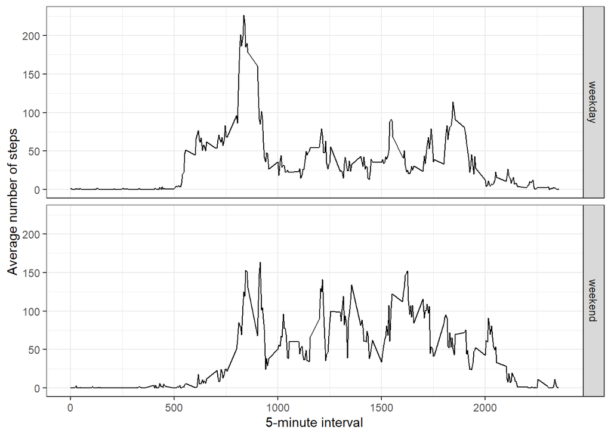

```r
activityDataImputed %>% group_by(DayType,interval) %>%
    summarize(mean_steps = mean(steps),.groups="drop") %>%
    ggplot( aes(interval, mean_steps)) +
    geom_line() +
    facet_grid(DayType ~ .) +
    xlab("5-minute interval") +
    ylab("Average number of steps") +
    theme_bw()
```